# Introduction to Likelihood

# R

- [Rstudio](https://rstudio.com)
- [R](https://www.r-project.org)
- [Short Intro to R](https://cran.r-project.org/doc/contrib/Torfs+Brauer-Short-R-Intro.pdf)

# Binomial Distirbution and Likelihood

## Binomial PDF

Probability density function (pdf), $\operatorname{Pr}(k)=\left(\begin{array}{l}n \\ k\end{array}\right) p^{k}(1-p)^{n-k}$

Let’s make a plot of Binomial pdf for n=10, and p=0.5

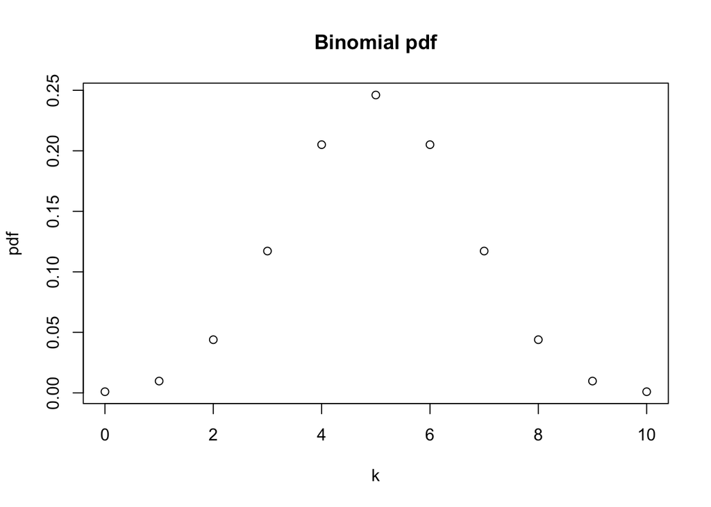

```r
k <- c(0:10)
pdf <- dbinom(x=k, size=10, p=0.5)
plot(k, pdf, main='Binomial pdf')
```

## Testing coins

Suppose we have two coins, one is fair, another is not. Let’s test which is fair using model selection. So, our experiment is the following:

1. Simulate fair coin
2. Calculate Ln under unfair model
3. Calculate Ln under fair model
4. Compare two models using AIC

Then,

5. Simulate unfair coin
6. Repeat the same step as above

Then test performance of AIC

7. Reduce number of tosses for both coins (e.g., n=3) and test if AIC still can distinguish between the two models
8. Binomial distribution is a simple model, so we have analytic solutions. However, let’s optimize Ln using optimization function.

#### Fair Coin

```r
# fair coin
c1 <- rbinom(n=1, size=100, prob=.5)
c1
```

```
## [1] 53
```

Likelihood function of the Binomial distribution:

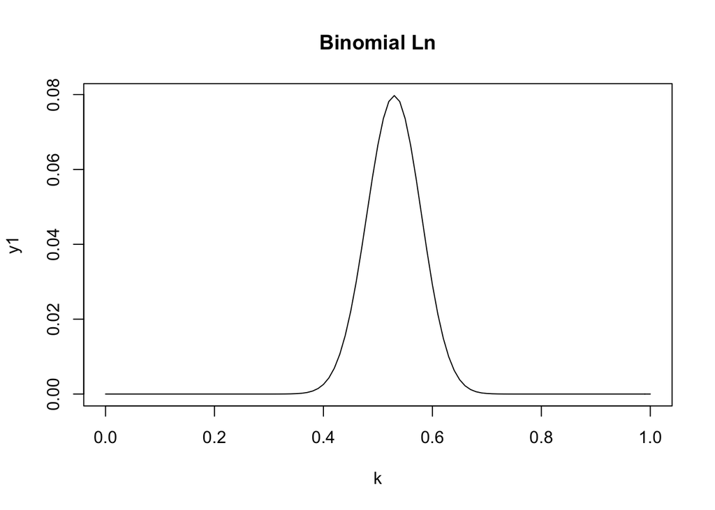

```r
# make likelihood plot
k <- seq(0,1,.01)
y1=dbinom(c1, 100, k)
plot(k, y1, type='l', main='Binomial Ln')
```

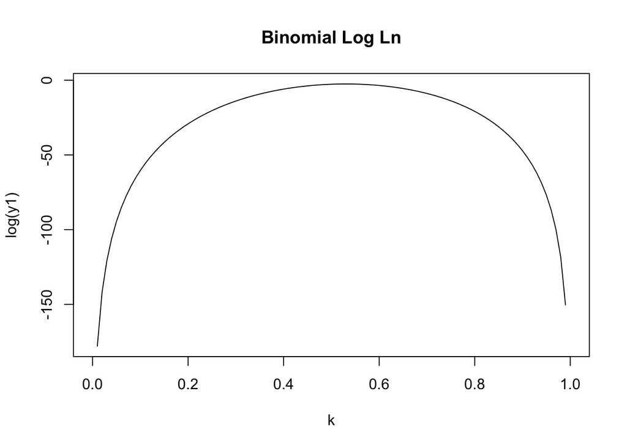

```r
# make log likelihood plot
plot(k, log(y1), type='l', main='Binomial Log Ln')
```

Let’s test fair/unfair models for the fair coin. Remember that maximum likelihood estimate for the probability parameter is $\hat{p}=k/n$, plugging it in the likelihood function gives maximum Ln value. Also, $\mathrm{AIC}=2 k-2 \ln (\hat{L})$

```r
# model one: p is estimated from data
p1.hat=c1/100
L1.est=dbinom(c1, size=100, prob=p1.hat)
# model two: p is assumed to be 0.5
L1.fair=dbinom(c1, size=100, prob=.5)

# AIC
AIC.m1=2*1-2*log(L1.est)
AIC.m2=2*0-2*log(L1.fair)

# delta AIC
AIC.m2-AIC.m1
```

```
## [1] -1.639784
```

#### Unfair Coin

```r
# unfair coin
c2 <- rbinom(n=1, size=100, prob=.7)
c2
```

```
## [1] 75
```

Likelihood and AIC

```r
L2.est=dbinom(c2, size=100, prob=c2/3)
L2.fair=dbinom(c2, size=3, prob=.5)

# AIC
AIC.c2.m1=2*1-2*log(L2.est)
AIC.c2.m2=2*0-2*log(L2.fair)

AIC.c2.m1-AIC.c2.m2
```

```
## [1] NaN
```

Now, play with the size parameter in *rbinom* as *rbinom(n=1, size=3, prob=…)*

### Finding Likelihood using optimization

We will use *optimize()* function for our estimation. *optimize()* function finds minima of input functions. So, we need to make our Ln negative.

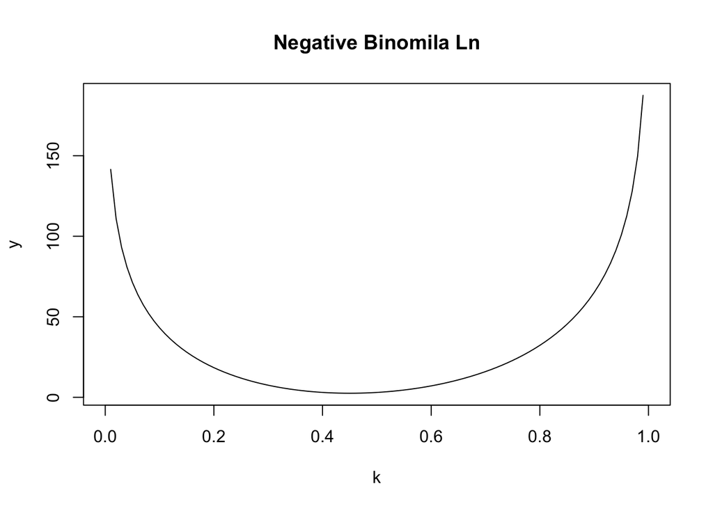

```r
# Let's make negative Ln custom function that we will be minimizing
Bin.ln <- function(par, size, k){

  -1*log(dbinom(k, size=size, prob=par))
}

# plot it
k <- seq(0,1,.01)
y=Bin.ln(par=k, size=100, k=45)
plot(k,y, type='l', main='Negative Binomila Ln')
```

```r
# using optimize to estimate p and max Ln for the coin 1s
res=optimize( Bin.ln, size=100, k=c1, lower = 0, upper = 1)
res
```

```
## $minimum
## [1] 0.5300001
##
## $objective
## [1] 2.529085
```

```r
# max Ln (converting from log units)
exp(res$objective*-1)
```

```
## [1] 0.07973193
```